# -

Adrian Cadena

# Intro

This is a “test” post that I decided to use to show people how I create HTML-format posts using R Markdown. People can follow the source code [here](https://github.com/adriancm93/website/blob/master/content/post/qb/index.Rmd).

# Metadata and format

This is the YAML front matter. Add this to line 1, including the `---` at start and end.

```
---
author: "Adrian Cadena"
date: "11-22-2020"
repository_url: https://github.com/adriancm93/mixed_effects_bootstrapping

output:
  html_document:
    toc: yes
    toc_depth: '3'
    df_print: paged
  distill::distill_article:
    self_contained: no
    toc: yes
    toc_depth: 3
---
```

To format R code chunks, use this code add ``` at start and end:

```
{r setup, include=FALSE}
knitr::opts_chunk$set(
  echo = TRUE,
  message = FALSE,
  warning = FALSE,
  dpi = 600,
  tidy = 'styler'
  )
```

# Font

This is the code I used to set the font size, right after the front matter.

```
<style type="text/css">
  body{
  font-size: 14pt;
}
</style>
```

# Non-R code

To add non-R code without it being run, like I did with front matter and font matter, add ``` at the start and end of such code.

# R code

You can run R code by inserting R code chunks. Refer to my [source code](https://github.com/adriancm93/website/blob/master/content/post/qb/index.Rmd).

You can change each block of code’s configurations by clicking on the engine icon on the top-right of the block. Show output only, show code and output, show nothing (run code), show nothing (don’t run code). If you want to show R code without running it, just use the ``` method we did earlier.

**R code not to run**

```
seasons <- 2000:2019
pbp <- purrr::map_df(seasons, function(x) {
  readRDS(
    url(
      glue::glue("https://raw.githubusercontent.com/guga31bb/nflfastR-data/master/data/play_by_play_{x}.rds")
    )
  )
})
```

**R code to run**

```r
print("This is a code block")
```

```
## [1] "This is a code block"
```

You can print **tables** and **plots**:

**Table**

```r
r <- read.csv("roster_data.csv")
r
```

| X.1 | X | team.season | teamPlayers.displayName | teamPlayers.firstName | teamPlayers.middleName | teamPlayers.lastName | teamPlayers.suffix | teamPlayers.status | teamPlayers.positionGroup | teamPlayers.position | teamPlayers.nflId | teamPlayers.esbId | teamPlayers.gsisId | teamPlayers.birthDate | teamPlayers.homeTown | teamPlayers.collegeId | teamPlayers.collegeName | teamPlayers.jerseyNumber | teamPlayers.height | teamPlayers.weight | team.teamId | team.abbr | team.cityState | team.fullName | team.nick | team.conferenceAbbr | team.divisionAbbr | teamPlayers.headshot_url | teamPlayers.profile_url |
| --- | --- | --- | --- | --- | --- | --- | --- | --- | --- | --- | --- | --- | --- | --- | --- | --- | --- | --- | --- | --- | --- | --- | --- | --- | --- | --- | --- | --- | --- |
| 1 | 56076 | 2019 | Marcus Smith | Marcus | McGuiel | Smith | II | CUT | LB | LB | 2543725 | SMI000009 | 00-0031371 | 03/31/1992 | Columbus, GA | 1838 | Louisville | 46 | 6-3 | 258 | 5110 | WAS | Washington | Washington Redskins | Redskins | NFC | NCE | http://static.nfl.com/static/content/public/static/img/fantasy/transparent/200x200/SMI000009.png | http://www.nfl.com/player/marcussmith/2543725/profile |
| 2 | 56077 | 2019 | Jerald Foster | Jerald | NA | Foster | NA | CUT | OL | OG | 2563277 | FOS449827 | 00-0035563 | 09/14/1995 | NA | 6877 | Nebraska | 63 | 6-3 | 305 | 5110 | WAS | Washington | Washington Redskins | Redskins | NFC | NCE | http://static.nfl.com/static/content/public/static/img/fantasy/transparent/200x200/FOS449827.png | http://www.nfl.com/player/jeraldfoster/2563277/profile |
| 3 | 56078 | 2019 | Deshazor Everett | Deshazor | Duntee' | Everett | NA | RES | DB | DB | 2553710 | EVE115531 | 00-0031844 | 02/22/1992 | Lake Charles, LA | 6003 | Texas A&M | 22 | 6-0 | 203 | 5110 | WAS | Washington | Washington Redskins | Redskins | NFC | NCE | http://static.nfl.com/static/content/public/static/img/fantasy/transparent/200x200/EVE115531.png | http://www.nfl.com/player/deshazoreverett/2553710/profile |
| 4 | 56079 | 2019 | Kenny Ladler | Kenny | Alfonzo | Ladler | Jr. | ACT | DB | DB | 2550365 | LAD432619 | 00-0030908 | 06/23/1992 | Lithonia, GA | 1871 | Vanderbilt | 33 | 6-0 | 200 | 5110 | WAS | Washington | Washington Redskins | Redskins | NFC | NCE | http://static.nfl.com/static/content/public/static/img/fantasy/transparent/200x200/LAD432619.png | http://www.nfl.com/player/kennyladler/2550365/profile |
| 5 | 56080 | 2019 | Ereck Flowers | Ereck | Guy | Flowers | NA | ACT | OL | OG | 2552452 | FLO325059 | 00-0032259 | 04/25/1994 | Topeka, KS | 5815 | Miami (Fla.) | 77 | 6-6 | 330 | 5110 | WAS | Washington | Washington Redskins | Redskins | NFC | NCE | http://static.nfl.com/static/content/public/static/img/fantasy/transparent/200x200/FLO325059.png | http://www.nfl.com/player/ereckflowers/2552452/profile |
| 6 | 56081 | 2019 | Marquis Flowers | Marquis | L. | Flowers | NA | CUT | LB | LB | 2549896 | FLO457902 | 00-0031290 | 02/16/1992 | Independence, MO | 4832 | Arizona | 50 | 6-2 | 250 | 5110 | WAS | Washington | Washington Redskins | Redskins | NFC | NCE | http://static.nfl.com/static/content/public/static/img/fantasy/transparent/200x200/FLO457902.png | http://www.nfl.com/player/marquisflowers/2549896/profile |

**Plots**

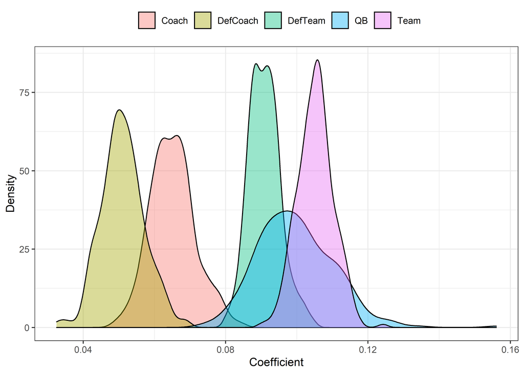

```r
library(ggplot2)

plot <- read.csv("analysis.csv")

p <- ggplot(plot, aes(x = coef, fill = effect)) +
  geom_density(alpha = .4) +
  theme_bw() +
  theme(
    legend.position = "top",
    legend.title = element_blank()
  ) +
  labs(x = "Coefficient", y = "Density") +
  ggsave("plot.png", dpi = 600, width = 8, height = 5, units = "in")

p
```

```r
# ![External image.](plot.png)
```

# Insert images

You can also insert images using the following code. Don’t add it to a code block.

```
![External image.](path/image.png)
```

Result:

[figure not shown]

# Convert to HTML

Click on “Knit” and select Knit to HTML.